# Reproducible Research: Peer Assessment 1

## Loading and preprocessing the data

```r
##install.packages("plyr")
library(plyr)

data <- read.csv("activity.csv", )
data$date <- as.Date(data$date, format = "%Y-%m-%d")
```

## What is mean total number of steps taken per day?

Total number of steps taken each day histogram:

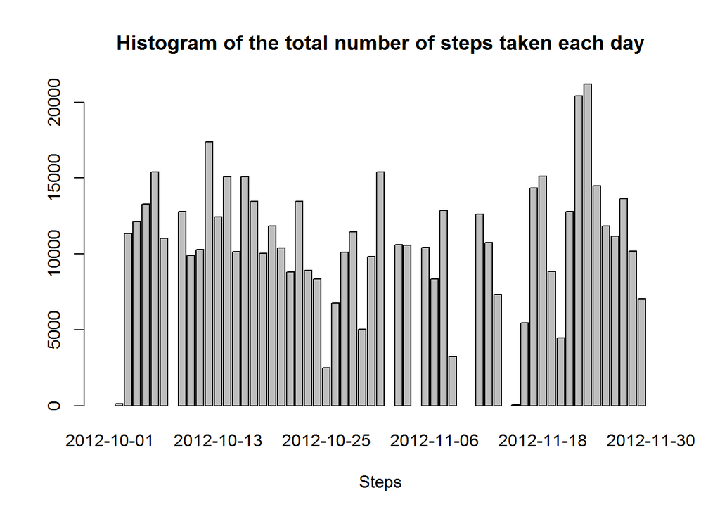

```r
dataSum <- ddply(data, .(date), summarise, steps = sum(steps))
barplot(dataSum$steps, names.arg=dataSum$date, main = "Histogram of the total number of steps taken each day", xlab = "Steps")
```

Calculating mean number of steps per day:

```r
sMean <- mean(dataSum$steps, na.rm = TRUE)
```

Mean is 1.0766 × 10<sup>4</sup>

Calculating median number of steps per day:

```r
sMedian <- median(dataSum$steps, na.rm = TRUE)
```

Median is 10765

## What is the average daily activity pattern?

Plot of the 5-minute interval (x-axis) and the average number of steps taken, averaged across all days (y-axis)

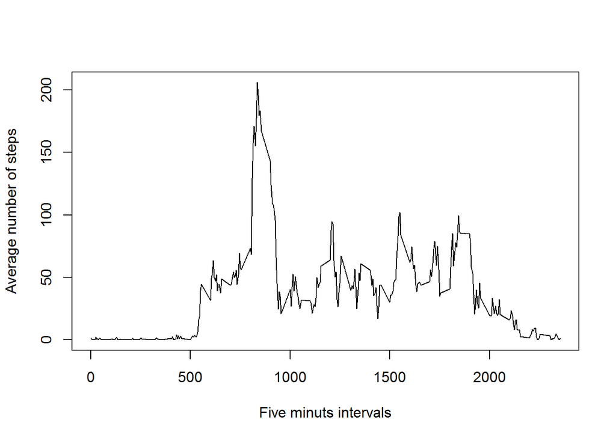

```r
avgStepsPerInterval <- ddply(data, .(interval), summarise, stepsMean = mean(steps, na.rm = TRUE))
plot(avgStepsPerInterval$interval, avgStepsPerInterval$stepsMean, type="l",xlab="Five minuts intervals", ylab="Average number of steps")
```

Interval, that contains the maximum number of steps

```r
maximumStepsInterval <- avgStepsPerInterval[avgStepsPerInterval$stepsMean == max(avgStepsPerInterval$stepsMean),1]
```

is 835

## Imputing missing values

```r
missingValuesCount <- sum(is.na(data))
```

Replacing NA with corresponded avgStepsPerInterval

```r
noNAData <- data
noNAData$date <- as.Date(data$date)
for (i in 1:length(data$steps)) {
    if (is.na(noNAData[i,1])) {
        noNAData[i,1] <- as.numeric(avgStepsPerInterval[(noNAData[i,3]==avgStepsPerInterval[,1]),2])
    }
}
```

Histogram of the total number of steps taken each day

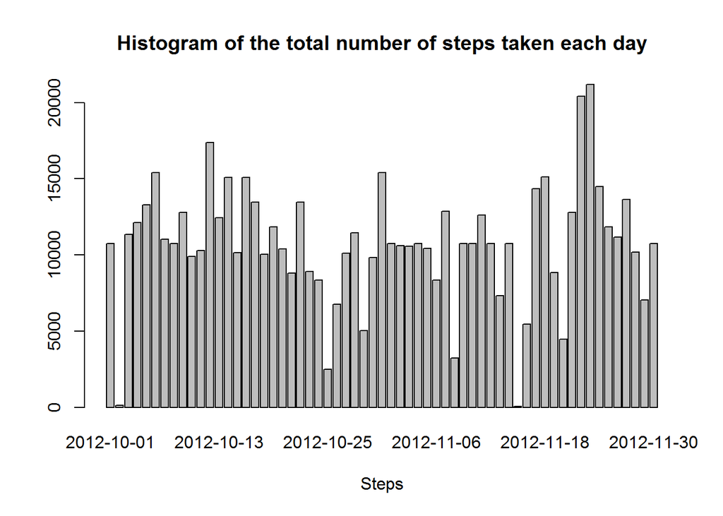

```r
noNAdataSum <- ddply(noNAData, .(date), summarise, steps = sum(steps))
barplot(noNAdataSum$steps, names.arg=noNAdataSum$date, main = "Histogram of the total number of steps taken each day", xlab = "Steps")
```

Calculating mean number of steps per day:

```r
sMean <- mean(noNAdataSum$steps, na.rm = TRUE)
```

Mean is 1.0766 × 10<sup>4</sup>

Calculating median number of steps per day:

```r
sMedian <- median(noNAdataSum$steps, na.rm = TRUE)
```

Median is 1.0766 × 10<sup>4</sup>

Values are not much differ from the estimates from the first part of the assignment There is no big impact of inputing missing data on the estimates of the total daily number of steps

## Are there differences in activity patterns between weekdays and weekends?

Ading new factor variable in the dataset with two levels – “weekday” and “weekend” indicating whether a given date is a weekday or weekend day

```r
weekday <- weekdays(noNAData$date, abbreviate = FALSE)
noNAData$weekdayOrWeekend <- vector(length=length(noNAData$steps))

noNAData$weekdayOrWeekend[weekday=="Saturday" | weekday=="Sunday"] <- "weekend"
noNAData$weekdayOrWeekend[weekday!="Saturday" & weekday!="Sunday"] <- "weekday"

noNAData$weekdayOrWeekend <- as.factor(noNAData$weekdayOrWeekend)
```

Making a panel plot containing a time series plot of the 5-minute interval (x-axis) and the average number of steps taken, averaged across all weekday days or weekend days (y-axis).

[figure not shown]

```r
avgStepsPerInterval <- ddply(noNAData, .(interval, weekdayOrWeekend), summarise, steps = mean(steps))

par(mfrow = c(2,1))
plot(avgStepsPerInterval[avgStepsPerInterval$weekdayOrWeekend=="weekend",1], avgStepsPerInterval[avgStepsPerInterval$weekdayOrWeekend=="weekend",3], main="weekend", type="l",xlab="Five minuts intervals", ylab="Average number of steps", xlim=c(0,250), ylim=c(0,250))
plot(avgStepsPerInterval[avgStepsPerInterval$weekdayOrWeekend=="weekday",1], avgStepsPerInterval[avgStepsPerInterval$weekdayOrWeekend=="weekday",3], main="weekday", type="l",xlab="Five minuts intervals", ylab="Average number of steps", xlim=c(0,250), ylim=c(0,250))
```